# Random Forest and Logistic Regression on Colinear Data

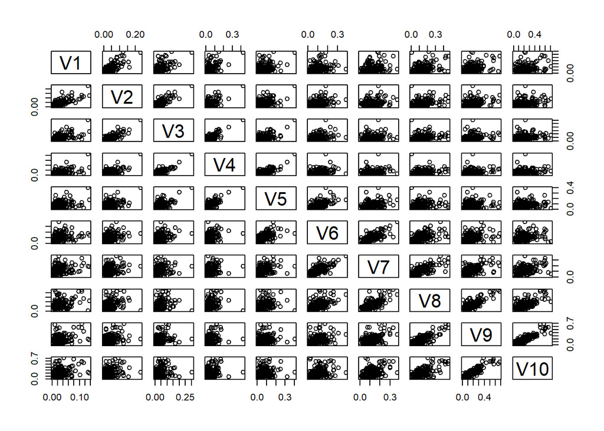

```r
par(mfrow = c(1,1))

# plot predictors against each other
plot(sonar[,1:10])  # it appears predictors next to each other are pretty similar
```

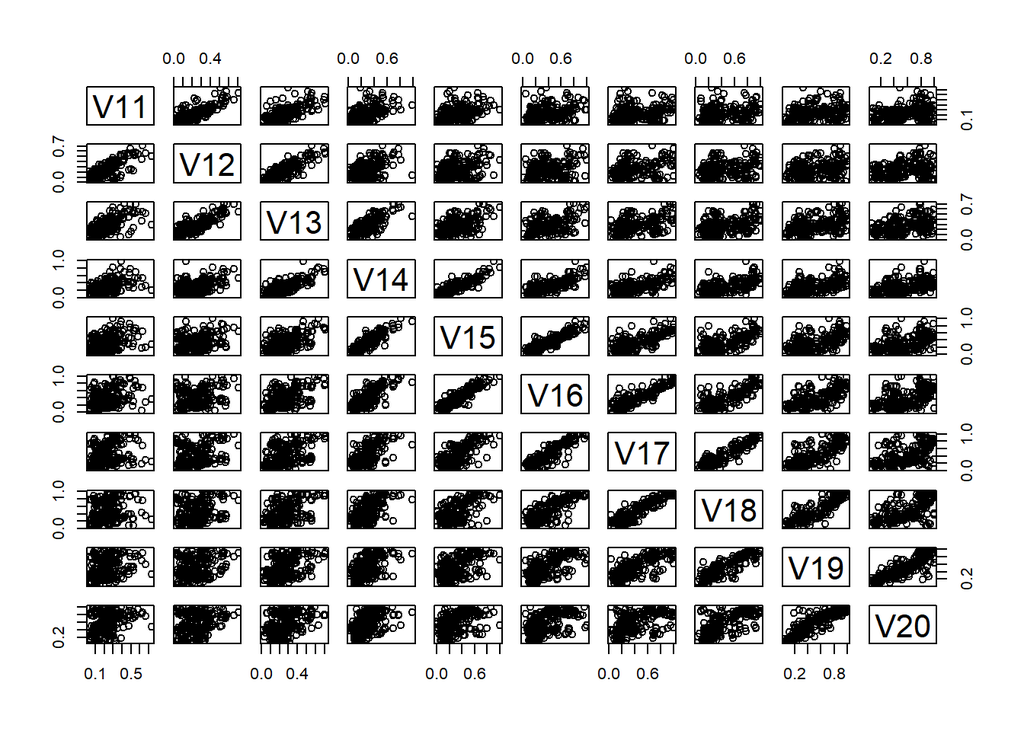

```r
plot(sonar[,11:20]) # this trend continues to most of the variables
```

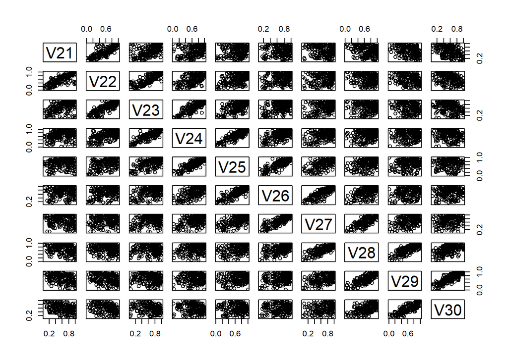

```r
plot(sonar[,21:30])
```

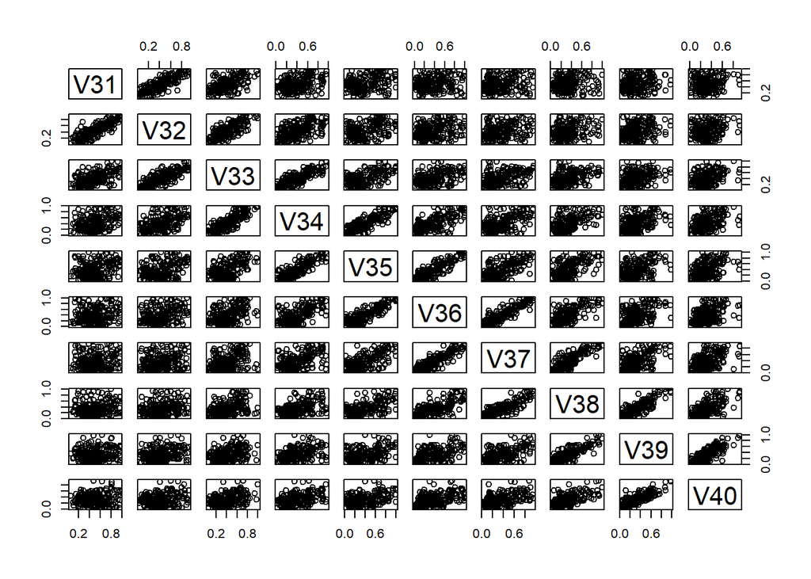

```r
plot(sonar[,31:40])
```

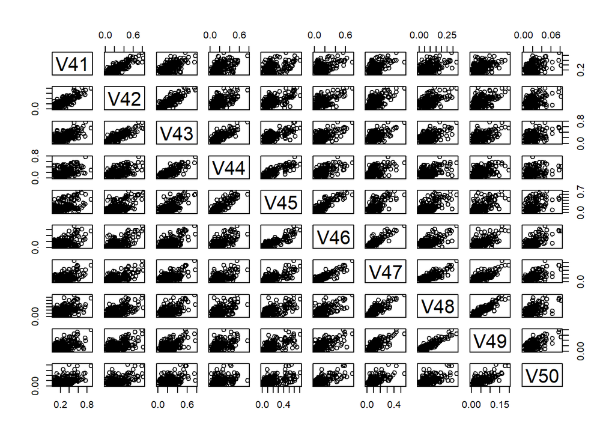

```r
plot(sonar[,41:50])
```

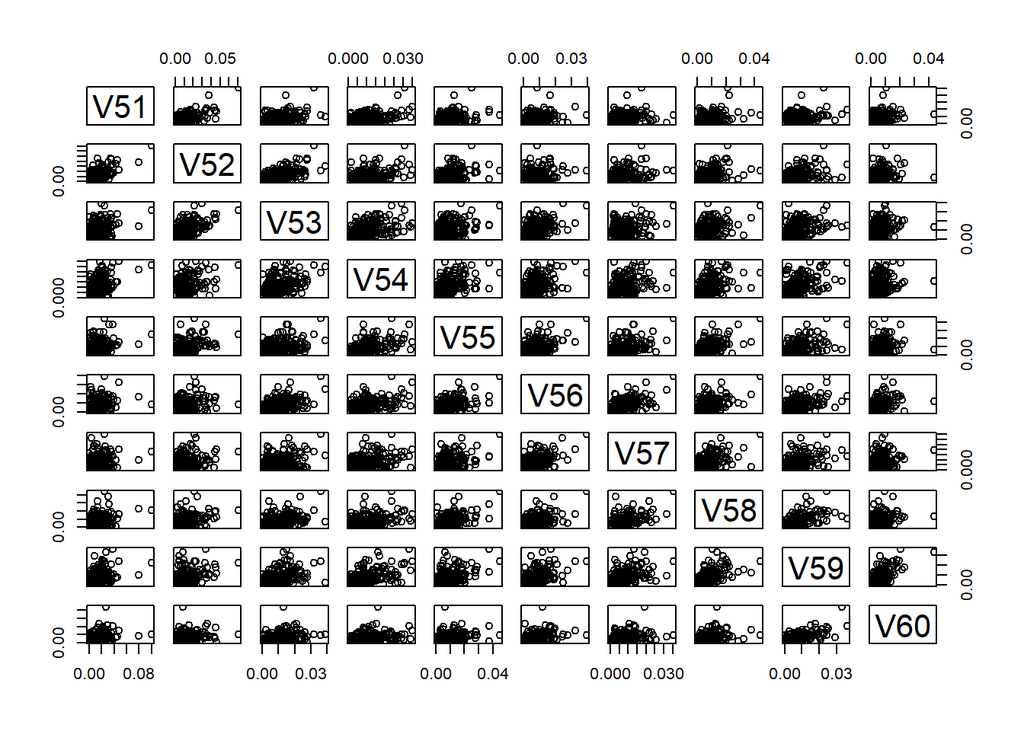

```r
plot(sonar[,51:60]) # less similarity between nearby predictors
```

## Logistic Regression

When considering a binary outcome, logistic regression is a natural option. First we check for colinearity.

```r
vifmod <- glm(Y~., data = sonar, family = "binomial")
vif(vifmod)
```

```
##           V1           V2           V3           V4           V5
## 6.964267e+11 1.612408e+11 1.930462e+12 1.773719e+11 4.543842e+10
##           V6           V7           V8           V9          V10
## 3.065797e+11 6.100918e+11 3.268454e+11 1.614654e+12 2.172716e+12
##          V11          V12          V13          V14          V15
## 1.429340e+12 8.737095e+11 2.996637e+12 1.777405e+12 8.643514e+11
##          V16          V17          V18          V19          V20
## 1.334711e+12 1.051617e+13 6.447469e+12 2.198652e+12 4.965173e+12
##          V21          V22          V23          V24          V25
## 3.676015e+12 5.442255e+12 1.010418e+13 1.077115e+13 4.973020e+12
##          V26          V27          V28          V29          V30
## 9.490096e+11 1.197985e+12 1.316924e+12 1.049774e+12 2.046653e+12
##          V31          V32          V33          V34          V35
## 1.065059e+12 2.331034e+12 4.419439e+12 5.016878e+11 3.348820e+12
##          V36          V37          V38          V39          V40
## 7.376100e+12 8.012819e+12 4.361783e+12 3.965658e+12 5.718774e+12
##          V41          V42          V43          V44          V45
## 6.985822e+12 4.127147e+12 4.386434e+12 3.038177e+12 3.070096e+12
##          V46          V47          V48          V49          V50
## 1.295868e+13 7.065387e+12 1.130067e+12 3.535046e+11 6.060124e+11
##          V51          V52          V53          V54          V55
## 7.188849e+11 1.737460e+11 3.770690e+11 2.577459e+11 6.007818e+10
##          V56          V57          V58          V59          V60
## 1.845978e+11 1.086903e+12 5.855238e+11 1.127415e+12 1.403952e+11
```

```r
# indicative of lots of collinearity.
# Since the variables don't have much context, remove largest VIF variable first
# removing variables till all VIF's are under 10

which.max(vif(vifmod))
```

```
## V46
##  46
```

```r
vifmod <- update(vifmod, .~.- V17)
vif(vifmod)
```

```
##           V1           V2           V3           V4           V5
## 1.466632e+12 1.351259e+12 3.055865e+11 7.305829e+11 1.295768e+12
##           V6           V7           V8           V9          V10
## 7.947115e+11 2.277053e+11 2.704126e+11 1.770135e+12 4.911105e+12
##          V11          V12          V13          V14          V15
## 6.236011e+12 2.542660e+12 1.595268e+12 3.292626e+12 5.376709e+12
##          V16          V18          V19          V20          V21
## 3.124332e+12 2.408931e+12 2.677780e+12 1.037955e+13 5.446126e+12
##          V22          V23          V24          V25          V26
## 3.615121e+12 6.015408e+12 4.300762e+12 1.223918e+12 4.355622e+11
##          V27          V28          V29          V30          V31
## 7.287327e+11 4.201523e+11 1.116117e+12 8.116383e+11 3.942846e+12
##          V32          V33          V34          V35          V36
## 1.779377e+12 1.009581e+12 7.695440e+11 2.449714e+12 6.601117e+12
##          V37          V38          V39          V40          V41
## 7.468826e+12 6.409019e+12 7.015051e+12 7.272187e+12 1.586398e+12
##          V42          V43          V44          V45          V46
## 1.747687e+12 1.210621e+12 8.778320e+11 1.875856e+12 5.717028e+12
##          V47          V48          V49          V50          V51
## 1.166860e+12 1.572251e+12 2.421690e+12 4.349381e+11 5.510603e+11
##          V52          V53          V54          V55          V56
## 4.654337e+11 4.351868e+11 2.068468e+11 5.376388e+11 2.323487e+11
##          V57          V58          V59          V60
## 2.307802e+11 4.884591e+11 3.113041e+11 2.002876e+11
```

```r
#
#  Multiple steps removed for space
#


which.max(vif(vifmod))
```

```
## V20
##  19
```

```r
vifmod <- update(vifmod, .~.- V48)
vif(vifmod)
```

```
##           V1           V2           V3           V4           V5
## 1.738413e+11 9.012196e+11 4.750152e+11 2.773800e+11 3.351371e+11
##           V6           V7           V8           V9          V10
## 8.456674e+10 3.578062e+11 4.820837e+11 7.194446e+11 6.978262e+11
##          V11          V12          V13          V14          V15
## 1.838103e+12 8.239033e+11 2.207987e+12 6.545140e+12 9.309538e+12
##          V16          V18          V19          V20          V21
## 4.446720e+12 9.139811e+11 1.292922e+12 5.225227e+12 3.641064e+12
##          V22          V23          V24          V25          V26
## 3.810919e+12 2.075850e+13 2.190931e+13 6.559255e+12 2.620604e+12
##          V27          V28          V29          V30          V31
## 3.434345e+12 1.981211e+12 1.250548e+12 1.822115e+12 1.393132e+12
##          V32          V33          V34          V35          V36
## 1.894954e+12 4.071725e+12 1.856386e+12 8.640127e+12 2.263219e+12
##          V37          V38          V39          V40          V41
## 9.546019e+11 4.172664e+12 2.168104e+12 1.839244e+12 2.407604e+12
##          V42          V43          V44          V45          V46
## 1.223308e+13 5.846062e+12 6.633429e+11 3.725040e+12 8.277071e+12
##          V47          V49          V50          V51          V52
## 5.083585e+12 1.834041e+12 3.105480e+11 6.810053e+11 2.549677e+11
##          V53          V54          V55          V56          V57
## 1.589107e+11 5.531066e+10 1.273674e+11 1.193252e+11 3.596451e+11
##          V58          V59          V60
## 1.363258e+12 1.722102e+12 7.671448e+11
```

```r
# create new dataset with non-collinear predictors so it's easier to build the model
newsonar <- sonar[,c(1:8, 10, 12:14, 16, 19, 21, 22, 24, 26, 27, 29, 30, 32, 34, 36, 38, 29, 41, 43, 44,
                     44, 47, 49:61)]
dim(newsonar)
```

```
## [1] 208  44
```

Many variables had to be removed to avoid colinearity. Although there are two variables that have a VIF over 10 (but less than 11), they were kept in. I am cautious of removing so many predictors in one step. A new data set is created after removing the correlated variables.

Before we build the model, we want to split the dataset into a training set and a test set. We use a 75% training, 25% test split.

```r
n <- length(sonar$Y) # number of observations

tr <- sample(1:n, size = floor(n*.75))  # note these random selection of observations will also be
t <- (1:n)[-tr]                         # used when building the random forest

train <- data.frame(newsonar[tr, ])
test <- data.frame(newsonar[t, ])

trainn <- length(tr)
testn <- length(t)
```

Now we can build the logistic model. We will take two approaches, using AIC stepwise selection and BIC stepwise selection. BIC will penalize for more variables.

```r
# AIC stepwise selection
fullmod <- glm(Y ~ ., data = train, family = "binomial")

AICmod <- step(fullmod, direction = "both", trace = FALSE)
summary(AICmod)
```

```
##
## Call:
## glm(formula = Y ~ V1 + V2 + V3 + V4 + V7 + V8 + V10 + V13 + V16 +
##     V19 + V21 + V22 + V24 + V27 + V30 + V32 + V34 + V49 + V50 +
##     V51 + V52 + V53 + V54 + V55 + V56 + V57 + V58 + V59, family = "binomial",
##     data = train)
##
## Deviance Residuals:
##      Min        1Q    Median        3Q       Max
## -1.93935  -0.04466   0.00000   0.06813   1.89976
##
## Coefficients:
##             Estimate Std. Error z value Pr(>|z|)
## (Intercept)   15.886      5.570   2.852 0.004343 **
## V1          -168.257     61.909  -2.718 0.006571 **
## V2            68.557     45.234   1.516 0.129615
## V3            81.965     40.503   2.024 0.043005 *
## V4           -92.129     32.195  -2.862 0.004215 **
## V7            45.384     17.585   2.581 0.009854 **
## V8            56.796     19.319   2.940 0.003283 **
## V10          -49.433     15.897  -3.110 0.001874 **
## V13          -20.494      7.793  -2.630 0.008541 **
## V16           16.989      5.473   3.104 0.001910 **
## V19           -9.484      4.382  -2.164 0.030452 *
## V21            9.920      5.179   1.915 0.055436 .
## V22          -13.940      6.226  -2.239 0.025159 *
## V24           -9.062      4.334  -2.091 0.036550 *
## V27            7.477      3.182   2.350 0.018797 *
## V30          -13.993      5.278  -2.651 0.008016 **
## V32           10.739      4.417   2.431 0.015059 *
## V34           13.625      4.580   2.975 0.002932 **
## V49         -157.557     46.571  -3.383 0.000717 ***
## V50          424.057    128.352   3.304 0.000954 ***
## V51         -462.275    140.334  -3.294 0.000987 ***
## V52         -244.531     94.973  -2.575 0.010032 *
## V53          185.159    116.242   1.593 0.111188
## V54         -590.971    196.095  -3.014 0.002581 **
## V55          587.508    211.390   2.779 0.005448 **
## V56         -719.886    233.962  -3.077 0.002091 **
## V57          473.122    134.168   3.526 0.000421 ***
## V58         -496.402    223.408  -2.222 0.026287 *
## V59          447.813    178.493   2.509 0.012112 *
## ---
## Signif. codes:  0 '***' 0.001 '**' 0.01 '*' 0.05 '.' 0.1 ' ' 1
##
## (Dispersion parameter for binomial family taken to be 1)
##
##     Null deviance: 215.620  on 155  degrees of freedom
## Residual deviance:  56.277  on 127  degrees of freedom
## AIC: 114.28
##
## Number of Fisher Scoring iterations: 10
```

```r
# Best model has V1, V4, V10, V12, V13, V14, V22, V26, V30, V36, V38, V41, V44, V47, V49
#                V50, V52, V54, V55, V57, V59, V60 as predictors

# BIC stepwise selection
BICmod <- step(fullmod, direction = "both", trace = FALSE, k = log(trainn))
summary(BICmod)
```

```
##
## Call:
## glm(formula = Y ~ V8 + V10 + V16 + V22 + V34 + V49 + V50 + V51 +
##     V52 + V54 + V56 + V57, family = "binomial", data = train)
##
## Deviance Residuals:
##      Min        1Q    Median        3Q       Max
## -2.10325  -0.49020  -0.00482   0.45079   2.38604
##
## Coefficients:
##             Estimate Std. Error z value Pr(>|z|)
## (Intercept)    5.948      1.430   4.159 3.19e-05 ***
## V8            14.373      4.940   2.909 0.003621 **
## V10          -14.479      3.610  -4.011 6.06e-05 ***
## V16            3.458      1.433   2.413 0.015817 *
## V22           -5.639      1.422  -3.965 7.33e-05 ***
## V34            4.036      1.380   2.925 0.003449 **
## V49          -57.777     15.362  -3.761 0.000169 ***
## V50          143.951     38.836   3.707 0.000210 ***
## V51         -150.084     42.750  -3.511 0.000447 ***
## V52          -96.646     41.835  -2.310 0.020878 *
## V54         -116.669     47.583  -2.452 0.014210 *
## V56         -153.143     58.887  -2.601 0.009306 **
## V57          164.709     54.487   3.023 0.002504 **
## ---
## Signif. codes:  0 '***' 0.001 '**' 0.01 '*' 0.05 '.' 0.1 ' ' 1
##
## (Dispersion parameter for binomial family taken to be 1)
##
##     Null deviance: 215.62  on 155  degrees of freedom
## Residual deviance: 103.66  on 143  degrees of freedom
## AIC: 129.66
##
## Number of Fisher Scoring iterations: 7
```

```r
# Best model has V1, V12, V14, V22, V30, V36, V38, V49, V50, V52, V59, V60
```

As expected, the model chosen using AIC selection has more predictors than the model chosen using BIC. To determine which model to use, we will use cross validation to find the model with the lowest error (root mean squared error, RMSE).

```r
AICcv <- cv.glm(train, AICmod, K=5)
(AICcv.e <- AICcv$delta[1])
```

```
## [1] 0.2459765
```

```r
BICcv <- cv.glm(train, BICmod, K=5)
(BICcv.e <- BICcv$delta[1])
```

```
## [1] 0.1372301
```

```r
# Appears BIC model has lower error, let's try K = 10, and LOO-CV just to be sure

AICcv <- cv.glm(train, AICmod, K=10)
(AICcv.e <- AICcv$delta[1])
```

```
## [1] 0.1747425
```

```r
BICcv <- cv.glm(train, BICmod, K=10)
(BICcv.e <- BICcv$delta[1])
```

```
## [1] 0.1410233
```

```r
# BIC still lower, try LOO CV

AICcv <- cv.glm(train, AICmod, K=trainn)
(AICcv.e <- AICcv$delta[1])
```

```
## [1] 0.1820783
```

```r
BICcv <- cv.glm(train, BICmod, K=trainn)
(BICcv.e <- BICcv$delta[1])
```

```
## [1] 0.1441201
```

```r
# BIC better all around

finalmod <- BICmod
```

After using k = 5, k= 10, and leave-one-out cross validation, the BIC model has the lowest error. The model chosen using BIC will be our final logistic regression model.

## Random Forest

Since the Sonar dataset is highly colinear, we consider a random forest instead. We will use the same training set and test set, but with all variables, unlike the logistic model which had many variables removed due to colinearity.

```r
ftrain <- data.frame(sonar[tr, ])
ftest <- data.frame(sonar[t, ])

# split into test/train sets with same indecies, but with all 60 predictors

rf1 <- randomForest(Y~., data = ftrain) #default 500 trees, not bad, how will increasing trees improve results?
rf1
```

```
##
## Call:
##  randomForest(formula = Y ~ ., data = ftrain)
##                Type of random forest: classification
##                      Number of trees: 500
## No. of variables tried at each split: 7
##
##         OOB estimate of  error rate: 17.95%
## Confusion matrix:
##    M  R class.error
## M 71 12   0.1445783
## R 16 57   0.2191781
```

```r
rf2 <- randomForest(Y~., data = ftrain, ntree = 1000) # still fast calculation, try more trees
rf2
```

```
##
## Call:
##  randomForest(formula = Y ~ ., data = ftrain, ntree = 1000)
##                Type of random forest: classification
##                      Number of trees: 1000
## No. of variables tried at each split: 7
##
##         OOB estimate of  error rate: 17.31%
## Confusion matrix:
##    M  R class.error
## M 73 10   0.1204819
## R 17 56   0.2328767
```

```r
rf3 <- randomForest(Y~., data = ftrain, ntree = 2000) # better than 1000, try more trees
rf3
```

```
##
## Call:
##  randomForest(formula = Y ~ ., data = ftrain, ntree = 2000)
##                Type of random forest: classification
##                      Number of trees: 2000
## No. of variables tried at each split: 7
##
##         OOB estimate of  error rate: 16.67%
## Confusion matrix:
##    M  R class.error
## M 73 10   0.1204819
## R 16 57   0.2191781
```

```r
# random attempt for the ROC graph to work: builds rf on training set then runs it on test set in same function
rf3.5 <- randomForest(x = ftrain[,1:60], y = ftrain[,61], xtest = ftest[,1:60], ytest = ftest[,61], ntree = 2000)
please <- rf3.5$test

rf4 <- randomForest(Y~., data = ftrain, ntree = 3000) # not substantially better prediction for more trees
rf4
```

```
##
## Call:
##  randomForest(formula = Y ~ ., data = ftrain, ntree = 3000)
##                Type of random forest: classification
##                      Number of trees: 3000
## No. of variables tried at each split: 7
##
##         OOB estimate of  error rate: 16.67%
## Confusion matrix:
##    M  R class.error
## M 74  9   0.1084337
## R 17 56   0.2328767
```

After building a model based on 1000, 2000, and 3000 trees, we chose the model with 2000 trees.

## Comparison

Now we want to test our models using the test dataset to see which performs better with lower error. For the logistic model, we use a threshold of 0.5 to determine whether an object is a rock or a mine.

```r
logte_pred <- predict.glm(finalmod, newdata = test, type = "response")
log_te <- data.frame(predictor = logte_pred, known.truth = test$Y)
log_te$predicted <- ifelse(log_te$predictor < 0.5,"M","R")
table(log_te$predicted, log_te$known.truth)
```

```
##
##      M  R
##   M 20 12
##   R  8 12
```

```r
rfte_pred <- predict(rf3, newdata = ftest, type = "response", norm.votes = TRUE, predict.all = FALSE, proximity = FALSE, nodes = FALSE)
rf_te <- data.frame(predicted = rfte_pred, known.truth = test$Y)
table(rf_te$predicted, rf_te$known.truth)
```

```
##
##      M  R
##   M 27  9
##   R  1 15
```

On the test data, the logistic model has 20 misclassifications while the random forest model only has 10 misclassifications. We can check the performance of each model using further calculations.

```r
### True Positive Rate (predicted mine, truly mine / true mines)
log_tpr <- round(sum(log_te$predicted == "M" & log_te$known.truth == "M")/sum(log_te$known.truth == "M"), 3)
rf_tpr <- round(sum(rf_te$predicted == "M" & rf_te$known.truth == "M")/sum(rf_te$known.truth == "M"), 3)

### False Postive Rate (predicted mine, truly rock / true rocks)
log_fpr <- round(sum(log_te$predicted == "R" & log_te$known.truth == "M")/sum(log_te$known.truth == "R"), 3)
rf_fpr <- round(sum(rf_te$predicted == "R" & rf_te$known.truth == "M")/sum(rf_te$known.truth == "R"), 3)

### False Negative Rate  (predicted rock, truly mine / true mines)
log_fnr <- round(sum(log_te$predicted == "M" & log_te$known.truth == "R")/sum(log_te$known.truth == "M"), 3)
rf_fnr <- round(sum(rf_te$predicted == "M" & rf_te$known.truth == "R")/sum(rf_te$known.truth == "M"), 3)


### Accuracy (correct predictions / all predictions)
log_ac <- round((sum(log_te$predicted == "M" & log_te$known.truth == "M") +
             sum(log_te$predicted == "R" & log_te$known.truth == "R"))/length(log_te[,2]), 3)
rf_ac <- round((sum(rf_te$predicted == "M" & rf_te$known.truth == "M") +
             sum(rf_te$predicted == "R" & rf_te$known.truth == "R"))/length(rf_te[,2]), 3)

### Precision (number of mines correctly identified to number of mines identified (correct & incorrect))
log_pr <- round(sum(log_te$predicted == "M" & log_te$known.truth == "M")/sum(log_te$predicted == "M"), 3)
rf_pr <- round(sum(rf_te$predicted == "M" & rf_te$known.truth == "M")/sum(rf_te$predicted == "M"), 3)


### Results in Table
lg <- cbind("logistic regression", log_tpr, log_fpr, log_fnr, log_pr, log_ac)
rff <- cbind("random forest", rf_tpr, rf_fpr, rf_fnr, rf_pr, rf_ac)
results <- data.frame(rbind(lg, rff))
colnames(results) <- c("method", "TPR", "FPR", "FNR", "Precision", "Accuracy")
results
```

```
##                method   TPR   FPR   FNR Precision Accuracy
## 1 logistic regression 0.714 0.333 0.429     0.625    0.615
## 2       random forest 0.964 0.042 0.321      0.75    0.808
```

In every measure, True Positive Rate, False Positive Rate, False Negative Rate, and Accuracy, the random forest model substantially outperforms the logistic regression model. The success of each model can also be displayed using an ROC curve.

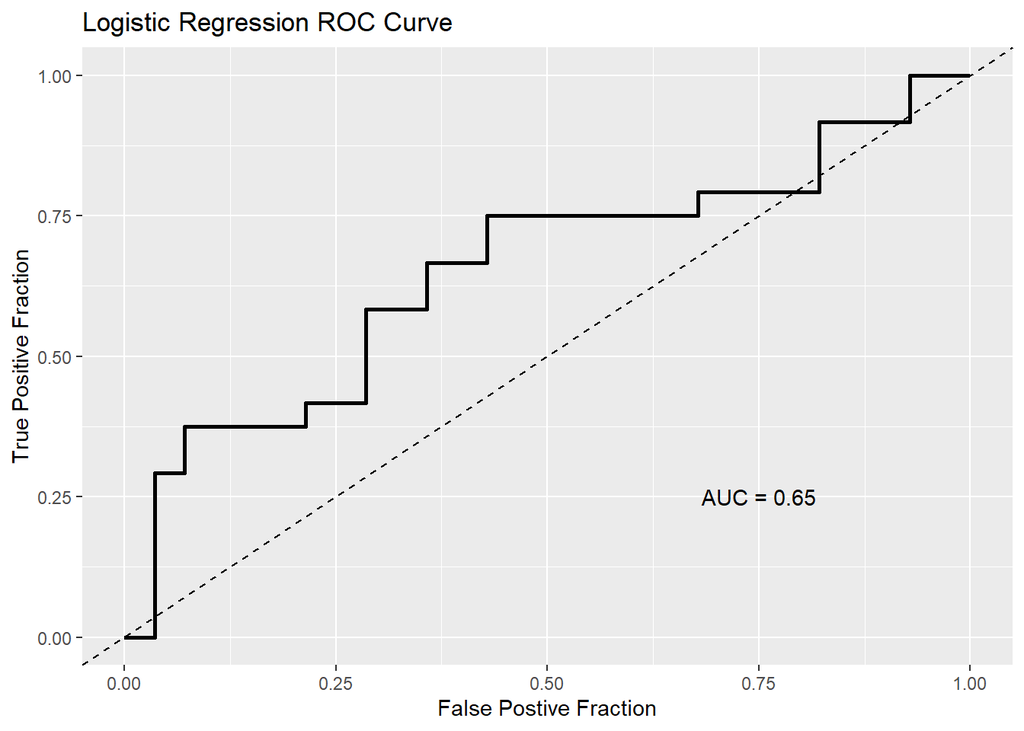

```r
threshold=0.5

df <- data.frame(predictor = logte_pred,known.truth = test$Y)
df$predicted.RM<-ifelse(df$predictor < threshold,0,1)
df$known.truth <- ifelse(df$known.truth=="M", 0, 1)

roc.plot<-ggplot(df, aes(d = known.truth, m = predictor)) +
  geom_roc(n.cuts = 0) + geom_abline(intercept = 0, slope = 1, linetype="dashed")

roc.plot + annotate("text", x = .75, y = .25, label = paste("AUC =", round(calc_auc(roc.plot)$AUC, 2)))+
  labs(title = "Logistic Regression ROC Curve", x = "False Postive Fraction", y = "True Positive Fraction")
```

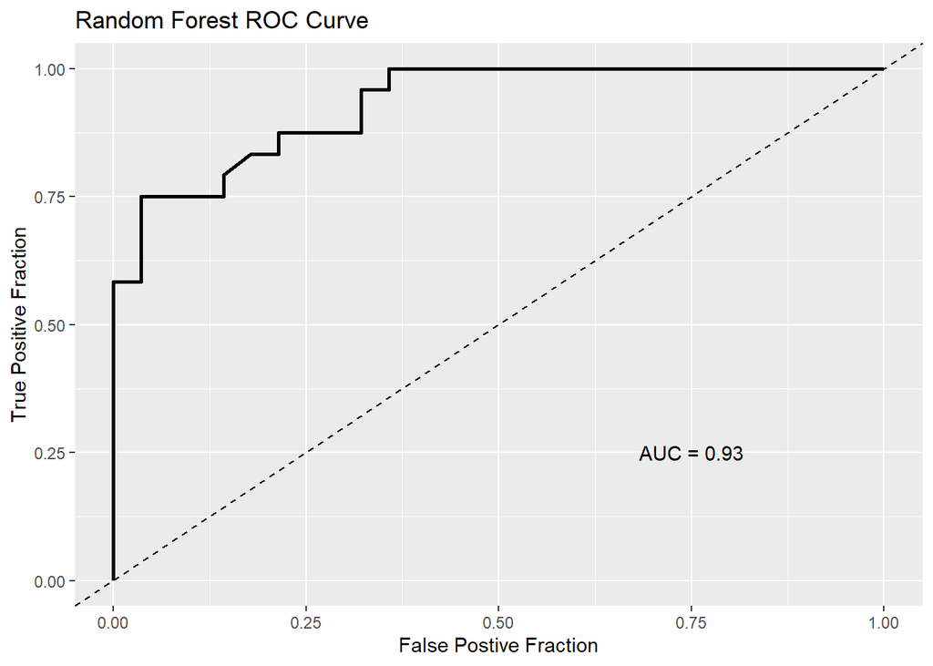

```r
df2 <- data.frame(predictor = please$votes[,2], known.truth = ftest$Y, predicted.RM <- rfte_pred)
df2$predicted.RM<-ifelse(df2$predictor<threshold,0,1)
df2$known.truth <- ifelse(df2$known.truth=="M", 0, 1)

roc.plot2<-ggplot(df2, aes(d = known.truth, m = predictor)) +
  geom_roc(n.cuts = 0) + geom_abline(intercept = 0, slope = 1, linetype="dashed")

roc.plot2 + annotate("text", x = .75, y = .25, label = paste("AUC =", round(calc_auc(roc.plot2)$AUC, 2)))+
  labs(title = "Random Forest ROC Curve", x = "False Postive Fraction", y = "True Positive Fraction")
```

A perfect model would result in an AUC=1, thus again, the random forest better predicts rocks or mines.

### References

Dua, D., & Graff, C. (2019). Machine Learning Repository. Retrieved from University of Caliofrnia, School of Information and Computer Science: http://archive.ics.uci.edu/ml

Kirasich, K., Smith, T., & Sadler, B. (2018). Random Forest vs Logistic Regression: Binary Classification for Heterogeneous Datasets. SMU Data Science Review. Retrieved from https://scholar.smu.edu/cgi/viewcontent.cgi?article=1041&context=datasciencereview

Oshiro, T. M., Perez, P. S., & Baranauskas, J. A. (n.d.). How Many Trees in a Random Forest? Machine Learning and Data Mining in Pattern Recognition, 154-168.